# Scoring Climatic Events By Population Health and Economic Impacts, Per-Event and All-Time

Akhil Kota

2022-07-25

## Synopsis

Using US NOAA’s Storm Data database, we have made an attempt to find the types of events that are (1) most harmful to health of the population, and (2) have the most severe economic effects. The data was first pre-processed to obtain reasonable metrics to gauge the health and economic effects. The metrics used for health were fatalities and injuries caused by the events, while the metrics used for economic impact were total economic damages, as a sum of property damages and crop damages. Then, the analysis was carried out by looking at the totals and averages of these metrics across event types, ranking these events by the totals/averages, and creating an overall “health score” or “economic outcome score” as a tool to determine which events had the greatest impacts. This approach was taken to account for both the per-event effect and the overall effect of any given event type on population health/economy.Through the analysis, we have found that (excessive/extreme) heat tends to produce the worst effects on population health, while hurricanes and storm surges produce the largest economic consequences.

## Data Processing

First, we download the data and load the file into R for analysis. Since the data is in a bzip2 file, we must load the data using the read.csv() function along with the bzfile() function, as done below. We start from this stage for reproducibility (no external pre-processing). We also load the dplyr library, which will be used in analysis.

```r
library(dplyr)
```

```r
library(ggplot2)
library(tidyr)
```

```r
if(!file.exists("storm_data.csv.bz2")){
    download.file("https://d396qusza40orc.cloudfront.net/repdata%2Fdata%2FStormData.csv.bz2",
                  "storm_data.csv.bz2")
}
dat <- read.csv(bzfile("storm_data.csv.bz2"))
```

Looking at the structure of our data frame, we see the following columns and classes:

```r
str(dat)
```

```
## 'data.frame':    902297 obs. of  37 variables:
##  $ STATE__   : num  1 1 1 1 1 1 1 1 1 1 ...
##  $ BGN_DATE  : chr  "4/18/1950 0:00:00" "4/18/1950 0:00:00" "2/20/1951 0:00:00" "6/8/1951 0:00:00" ...
##  $ BGN_TIME  : chr  "0130" "0145" "1600" "0900" ...
##  $ TIME_ZONE : chr  "CST" "CST" "CST" "CST" ...
##  $ COUNTY    : num  97 3 57 89 43 77 9 123 125 57 ...
##  $ COUNTYNAME: chr  "MOBILE" "BALDWIN" "FAYETTE" "MADISON" ...
##  $ STATE     : chr  "AL" "AL" "AL" "AL" ...
##  $ EVTYPE    : chr  "TORNADO" "TORNADO" "TORNADO" "TORNADO" ...
##  $ BGN_RANGE : num  0 0 0 0 0 0 0 0 0 0 ...
##  $ BGN_AZI   : chr  "" "" "" "" ...
##  $ BGN_LOCATI: chr  "" "" "" "" ...
##  $ END_DATE  : chr  "" "" "" "" ...
##  $ END_TIME  : chr  "" "" "" "" ...
##  $ COUNTY_END: num  0 0 0 0 0 0 0 0 0 0 ...
```

[output cut: 23 more lines]

If restricted to these data, human health can only be gauged using the FATALITIES and INJURIES data. These columns already have well-typed values, so no pre-processing is needed here.

On the other hand, we will need to use PROPDMG, PROPDMGEXP, CROPDMG and CROPDMGEXP to evaluate economic consequences across climate events. The DMGEXP variables are character representations of what power of ten needs to be multiplied by the DMG to get the total cost of a given event, so we will go through the data and combine the DMG and DMGEXP to get TOTAL_PROP_DMG and TOTAL_CROP_DMG, which contain a numeric value for the cost. Adding these two columns can get us the TOTAL_ECON_DMG for any given event.

To do this, we first need to look at the unique values in each of the DMGEXP columns.

```r
unique(dat$PROPDMGEXP)
```

```
##  [1] "K" "M" ""  "B" "m" "+" "0" "5" "6" "?" "4" "2" "3" "h" "7" "H" "-" "1" "8"
```

```r
unique(dat$CROPDMGEXP)
```

```
## [1] ""  "M" "K" "m" "B" "?" "0" "k" "2"
```

The numbers represent the magnitude, or exponent of ten, of the PROPDMG or CROPDMG. The letters “H”, K”, “M”, “B” represent hundred, thousand, million, and billion, respectively. Let’s get rid of letters and other symbols in favor of numbers first, and then turn the DMGEXP columns into numerics to ease our next pre-processing steps. The columns are copied into a separate variable first for safety.

```r
proc_pde <- sub("[Hh]", "2", dat$PROPDMGEXP)
proc_pde <- sub("[Kk]", "3", proc_pde)
proc_pde <- sub("[Mm]", "6", proc_pde)
proc_pde <- sub("[Bb]", "9", proc_pde)
unique(proc_pde)
```

```
##  [1] "3" "6" ""  "9" "+" "0" "5" "?" "4" "2" "7" "-" "1" "8"
```

```r
proc_cde <- sub("[Hh]", "2", dat$CROPDMGEXP)
proc_cde <- sub("[Kk]", "3", proc_cde)
proc_cde <- sub("[Mm]", "6", proc_cde)
proc_cde <- sub("[Bb]", "9", proc_cde)
unique(proc_cde)
```

```
## [1] ""  "6" "3" "9" "?" "0" "2"
```

Now, we need to deal with the special characters, “+”, “-”, “?” and ““. For”+” and “-”, we can reasonably replace these with “0”, since the order of magnitude will likely be around the same as the give damage value.

```r
proc_pde <- sub("(\\+)|(-)", "0", proc_pde)
proc_cde <- sub("(\\+)|(-)", "0", proc_cde)
```

Now, let’s look at the values in the damage column where “?” and “” are used.

```r
unique(subset(dat, PROPDMGEXP=="?")$PROPDMG)
```

```
## [1] 0
```

```r
unique(subset(dat, CROPDMGEXP=="?")$CROPDMG)
```

```
## [1] 0
```

```r
unique(subset(dat, PROPDMGEXP=="")$PROPDMG)
```

```
##  [1]  0.00  0.41  3.00  2.00  4.00 10.00  5.00 35.00 75.00  1.00 20.00  6.00
## [13]  7.00  9.00  8.00
```

```r
unique(subset(dat, CROPDMGEXP=="")$CROPDMG)
```

```
## [1] 0 3 4
```

So the “?” and “” can both be reasonably replaced by 0. Then, we transform the processed column copies into numerics and input them into the data frame.

```r
proc_pde <- sub("(\\?)|(^$)", "0", proc_pde)
proc_cde <- sub("(\\?)|(^$)", "0", proc_cde)

proc_pde <- as.numeric(proc_pde)
proc_cde <- as.numeric(proc_cde)

dat$PROPDMGEXP <- proc_pde
dat$CROPDMGEXP <- proc_cde

rm(list=c("proc_pde","proc_cde"))
```

Now, we can check that the four damage columns are now numerics without NA’s.

```r
str(select(dat, PROPDMG:CROPDMGEXP))
```

```
## 'data.frame':    902297 obs. of  4 variables:
##  $ PROPDMG   : num  25 2.5 25 2.5 2.5 2.5 2.5 2.5 25 25 ...
##  $ PROPDMGEXP: num  3 3 3 3 3 3 3 3 3 3 ...
##  $ CROPDMG   : num  0 0 0 0 0 0 0 0 0 0 ...
##  $ CROPDMGEXP: num  0 0 0 0 0 0 0 0 0 0 ...
```

```r
sum(is.na(select(dat, PROPDMG:CROPDMGEXP)))
```

```
## [1] 0
```

Lastly, we combine the columns DMG and DMGEXP for PROP and CROP into TOTALPROPDMG and TOTALCROPDMG, which are then added to get TOTALECONDMG.

```r
df <- dat %>%
    mutate(TOTALPROPDMG = (PROPDMG *(10^PROPDMGEXP)),
           TOTALCROPDMG = (CROPDMG *(10^CROPDMGEXP))) %>%
    mutate(TOTALECONDMG = TOTALPROPDMG + TOTALCROPDMG)
```

We can check that this operation worked by looking at the first element where TOTALPROPDMG and TOTALCROPDMG are nonzero.

```r
select(
    head(subset(df, TOTALPROPDMG!=0 & TOTALCROPDMG!=0), 1),
    PROPDMG:CROPDMGEXP, TOTALPROPDMG:TOTALECONDMG
)
```

```
##        PROPDMG PROPDMGEXP CROPDMG CROPDMGEXP TOTALPROPDMG TOTALCROPDMG
## 187566     0.1          9      10          6        1e+08        1e+07
##        TOTALECONDMG
## 187566      1.1e+08
```

This is, in fact, the expected result.

Now, we will trim down our dataset for analysis and clear up some memory. We will be constructing 2 new data frames: one with health data (averages and totals of fatalities and injuries) by event type and one with economic data (averages and totals of property damage, crop damage, and total damage) by event type. We will also be clearing unnecessary data to free up memory.

```r
health_data <- df %>%
    group_by(EVTYPE) %>%
    summarize(
        count=n(),
        total_fatal=sum(FATALITIES),
        total_inj=sum(INJURIES),
        avg_fatal=mean(FATALITIES),
        avg_inj=mean(INJURIES)
    ) %>%
    rename(event_type=EVTYPE)
econ_data <- df %>%
    group_by(EVTYPE) %>%
    summarize(
        count=n(),
        total_dmg=sum(TOTALECONDMG),
        avg_dmg=mean(TOTALECONDMG)
    ) %>%
    rename(event_type=EVTYPE)
rm("dat")
```

We can now delve into these prepared data sets and analyze health and economic outcomes by event type.

## Health Data Analysis

We seek to the answer the question of what event type are most harmful to population health. To do this, we will look at the health_data table constructed in the Data Processing section, sorted by most average fatalities and most average injuries.

```r
head(arrange(health_data, desc(avg_fatal)), 10)
```

```
## # A tibble: 10 × 6
##    event_type                 count total_fatal total_inj avg_fatal avg_inj
##    <chr>                      <int>       <dbl>     <dbl>     <dbl>   <dbl>
##  1 TORNADOES, TSTM WIND, HAIL     1          25         0     25       0
##  2 COLD AND SNOW                  1          14         0     14       0
##  3 TROPICAL STORM GORDON          1           8        43      8      43
##  4 RECORD/EXCESSIVE HEAT          3          17         0      5.67    0
##  5 EXTREME HEAT                  22          96       155      4.36    7.05
##  6 HEAT WAVE DROUGHT              1           4        15      4      15
##  7 HIGH WIND/SEAS                 1           4         0      4       0
##  8 MARINE MISHAP                  2           7         5      3.5     2.5
##  9 WINTER STORMS                  3          10        17      3.33    5.67
## 10 Heavy surf and wind            1           3         0      3       0
```

```r
head(arrange(health_data, desc(avg_inj)), 10)
```

```
## # A tibble: 10 × 6
##    event_type              count total_fatal total_inj avg_fatal avg_inj
##    <chr>                   <int>       <dbl>     <dbl>     <dbl>   <dbl>
##  1 Heat Wave                   1           0        70     0        70
##  2 TROPICAL STORM GORDON       1           8        43     8        43
##  3 WILD FIRES                  4           3       150     0.75     37.5
##  4 THUNDERSTORMW               1           0        27     0        27
##  5 HIGH WIND AND SEAS          1           3        20     3        20
##  6 SNOW/HIGH WINDS             2           0        36     0        18
##  7 GLAZE/ICE STORM             1           0        15     0        15
##  8 HEAT WAVE DROUGHT           1           4        15     4        15
##  9 WINTER STORM HIGH WINDS     1           1        15     1        15
## 10 HURRICANE/TYPHOON          88          64      1275     0.727    14.5
```

There seem to be several “one-off” low-count type events that are popping up at the top of the list. Since we are looking for harm to population health across the US, let’s discard these in some way. For now, we have chosen to look at only the event types with at least 10 events in count. Looking at this data

```r
pruned_health_data <- subset(health_data, count>=10)
head(arrange(pruned_health_data, desc(avg_fatal)), 10)
```

```
## # A tibble: 10 × 6
##    event_type                count total_fatal total_inj avg_fatal avg_inj
##    <chr>                     <int>       <dbl>     <dbl>     <dbl>   <dbl>
##  1 EXTREME HEAT                 22          96       155     4.36    7.05
##  2 HEAT WAVE                    74         172       309     2.32    4.18
##  3 UNSEASONABLY WARM AND DRY    13          29         0     2.23    0
##  4 TSUNAMI                      20          33       129     1.65    6.45
##  5 HEAT                        767         937      2100     1.22    2.74
##  6 EXCESSIVE HEAT             1678        1903      6525     1.13    3.89
##  7 RIP CURRENT                 470         368       232     0.783   0.494
##  8 HURRICANE/TYPHOON            88          64      1275     0.727  14.5
##  9 RIP CURRENTS                304         204       297     0.671   0.977
## 10 FLASH FLOOD/FLOOD            22          14         0     0.636   0
```

```r
head(arrange(pruned_health_data, desc(avg_inj)), 10)
```

```
## # A tibble: 10 × 6
##    event_type        count total_fatal total_inj avg_fatal avg_inj
##    <chr>             <int>       <dbl>     <dbl>     <dbl>   <dbl>
##  1 HURRICANE/TYPHOON    88          64      1275    0.727    14.5
##  2 EXTREME HEAT         22          96       155    4.36      7.05
##  3 GLAZE                32           7       216    0.219     6.75
##  4 TSUNAMI              20          33       129    1.65      6.45
##  5 HEAT WAVE            74         172       309    2.32      4.18
##  6 EXCESSIVE HEAT     1678        1903      6525    1.13      3.89
##  7 HEAT                767         937      2100    1.22      2.74
##  8 MIXED PRECIP         10           2        26    0.2       2.6
##  9 ICE                  61           6       137    0.0984    2.25
## 10 SNOW SQUALL          19           2        35    0.105     1.84
```

At the top of both lists, we see excessive/extreme heat-related event types. It does seem that the data holds several event types for the same/similar events, but this is not an issue for our basic analyses.

Now, let’s look at the pruned data by total fatalities and injuries. This will tend to make events with higher count naturally rise to the top anyways, and also accounts somewhat for some events being more common than others, and so more injurious to population health.

```r
head(arrange(pruned_health_data, desc(total_fatal)), 10)
```

```
## # A tibble: 10 × 6
##    event_type      count total_fatal total_inj avg_fatal avg_inj
##    <chr>           <int>       <dbl>     <dbl>     <dbl>   <dbl>
##  1 TORNADO         60652        5633     91346   0.0929   1.51
##  2 EXCESSIVE HEAT   1678        1903      6525   1.13     3.89
##  3 FLASH FLOOD     54277         978      1777   0.0180   0.0327
##  4 HEAT              767         937      2100   1.22     2.74
##  5 LIGHTNING       15754         816      5230   0.0518   0.332
##  6 TSTM WIND      219940         504      6957   0.00229  0.0316
##  7 FLOOD           25326         470      6789   0.0186   0.268
##  8 RIP CURRENT       470         368       232   0.783    0.494
##  9 HIGH WIND       20212         248      1137   0.0123   0.0563
## 10 AVALANCHE         386         224       170   0.580    0.440
```

```r
head(arrange(pruned_health_data, desc(total_inj)), 10)
```

```
## # A tibble: 10 × 6
##    event_type         count total_fatal total_inj avg_fatal avg_inj
##    <chr>              <int>       <dbl>     <dbl>     <dbl>   <dbl>
##  1 TORNADO            60652        5633     91346 0.0929    1.51
##  2 TSTM WIND         219940         504      6957 0.00229   0.0316
##  3 FLOOD              25326         470      6789 0.0186    0.268
##  4 EXCESSIVE HEAT      1678        1903      6525 1.13      3.89
##  5 LIGHTNING          15754         816      5230 0.0518    0.332
##  6 HEAT                 767         937      2100 1.22      2.74
##  7 ICE STORM           2006          89      1975 0.0444    0.985
##  8 FLASH FLOOD        54277         978      1777 0.0180    0.0327
##  9 THUNDERSTORM WIND  82563         133      1488 0.00161   0.0180
## 10 HAIL              288661          15      1361 0.0000520 0.00471
```

The only event types that occur in both the worst 10 average and worst 10 total lists are excessive heat-related types and rip current-related types. We can make this a bit more precise by finding the rank (given as a “score”) of every event in each of these lists, and finding the sum of these “scores” as an overall “health harm score”. The item with the lowest “health score” can then be chosen as the most harmful to health. This procedure will help to account for both average harm to health, and frequency of harm to health (using the totals).

```r
ranked_health_data <- pruned_health_data %>%
    mutate(
        avg_fatal_score = 0,
        avg_inj_score = 0,
        total_fatal_score = 0,
        total_inj_score = 0
    )
for(x in 1:nrow(ranked_health_data)) {
    ranked_health_data[x,]$avg_fatal_score = head(which(
        arrange(pruned_health_data, desc(avg_fatal))$avg_fatal==ranked_health_data[x,]$avg_fatal
    ),1)
    ranked_health_data[x,]$avg_inj_score = head(which(
        arrange(pruned_health_data, desc(avg_inj))$avg_inj==ranked_health_data[x,]$avg_inj
    ),1)
    ranked_health_data[x,]$total_fatal_score = head(which(
        arrange(pruned_health_data, desc(total_fatal))$total_fatal==ranked_health_data[x,]$total_fatal
    ),1)
    ranked_health_data[x,]$total_inj_score = head(which(
        arrange(pruned_health_data, desc(total_inj))$total_inj==ranked_health_data[x,]$total_inj
    ),1)
}
ranked_health_data <- mutate(ranked_health_data,
                             health_score = avg_fatal_score + avg_inj_score + total_fatal_score + total_inj_score)
select(head(arrange(ranked_health_data, health_score), 10), event_type, avg_fatal_score:health_score)
```

```
## # A tibble: 10 × 6
##    event_type     avg_fatal_score avg_inj_score total_fatal_sco… total_inj_score
##    <chr>                    <dbl>         <dbl>            <dbl>           <dbl>
##  1 EXCESSIVE HEAT               6             6                2               4
##  2 HEAT                         5             7                4               6
##  3 HEAT WAVE                    2             5               13              24
##  4 TORNADO                     30            12                1               1
##  5 HURRICANE/TYP…               8             1               26              12
##  6 EXTREME HEAT                 1             2               22              33
##  7 RIP CURRENTS                 9            18               12              26
##  8 RIP CURRENT                  7            23                8              29
##  9 TSUNAMI                      4             4               35              36
## 10 AVALANCHE                   11            28               10              32
## # … with 1 more variable: health_score <dbl>
```

So once again, it appears that **heat and excessive heat** have, far and away, the worst overall effects on population health. We visualize all the given scores in the bar plot below for the 5 events with the worst health score. Remember: lower score is bad!

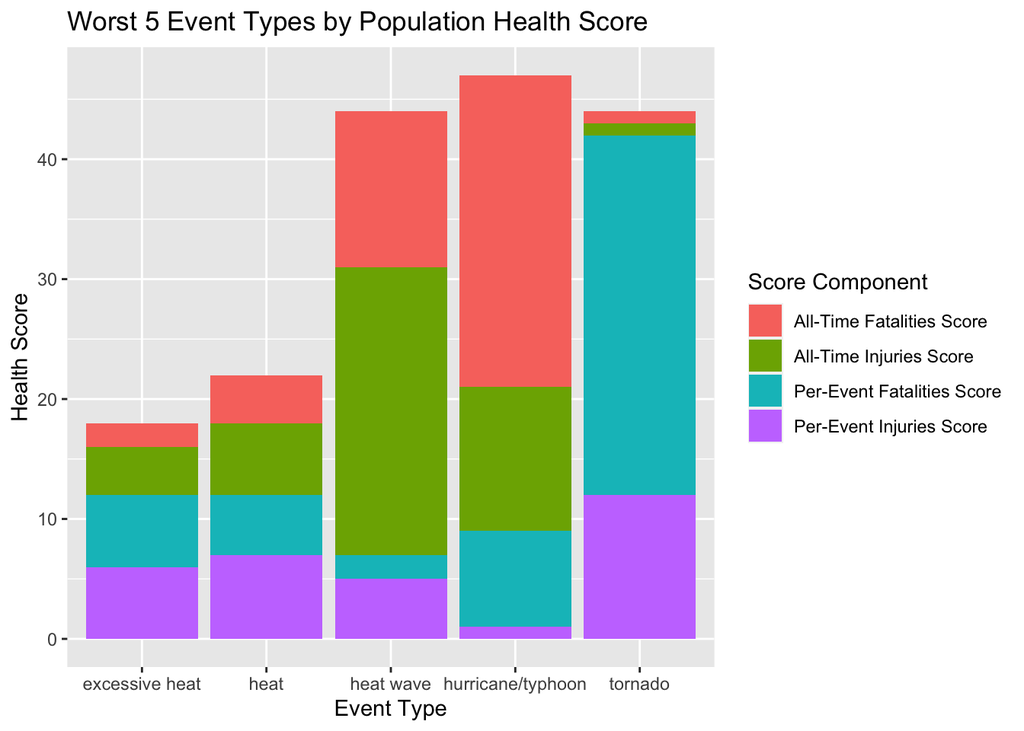

```r
worst_event_ranks <- head(arrange(ranked_health_data, health_score), 5) %>%
    select(event_type, avg_fatal_score:total_inj_score)
health_plot_data <- gather(worst_event_ranks, "score_type","score",-event_type)
health_plot_data$event_type <- tolower(health_plot_data$event_type)
health_plot_data$score_type <- gsub("avg_fatal_score", "Per-Event Fatalities Score", health_plot_data$score_type)
health_plot_data$score_type <- gsub("total_fatal_score", "All-Time Fatalities Score", health_plot_data$score_type)
health_plot_data$score_type <- gsub("avg_inj_score", "Per-Event Injuries Score", health_plot_data$score_type)
health_plot_data$score_type <- gsub("total_inj_score", "All-Time Injuries Score", health_plot_data$score_type)

g <- ggplot(health_plot_data, aes(x=event_type, y=score, fill=score_type))
g <- g + geom_bar(stat="identity")
g <- g + labs(x = "Event Type", y = "Health Score", fill = "Score Component")
g <- g + labs(title = "Worst 5 Event Types by Population Health Score")
g
```

*This plot visualizes health effects by the top 5 worst events types for population health, based on our calculated health score metric. First, we calculated average fatalities/injuries per event and total fatalities/injuries over all events of a specific type. Then, these metrics were ranked/scored over all event types and summed to get the health score. Each of these component ranks/scores are displayed in the plot above. The figure shows that excessive heat and heat have the worst impact on population health, per our analysis.*

## Economic Data Analysis

We will carry out a similar analysis for the economic data as we have done for the health data above, attributing ranks to each event type based on average damage costs per event and total damage costs over all events of an event type. This will be used to create an “economic outcome score”, which will then be used to make a claim as to what event type causes the worst economic consequences. Only total damages matter are to be analyzed here, so the property damage vs, crop damage breakdown is not relevant to this analysis.

```r
pruned_econ_data <- subset(econ_data, count>=10)
ranked_econ_data <- pruned_econ_data %>%
    mutate(
        avg_dmg_score = 0,
        total_dmg_score = 0
    )
for(x in 1:nrow(ranked_econ_data)) {
    ranked_econ_data[x,]$avg_dmg_score = head(which(
        arrange(pruned_econ_data, desc(avg_dmg))$avg_dmg==ranked_econ_data[x,]$avg_dmg
    ),1)
    ranked_econ_data[x,]$total_dmg_score = head(which(
        arrange(pruned_econ_data, desc(total_dmg))$total_dmg==ranked_econ_data[x,]$total_dmg
    ),1)
}
ranked_econ_data <- mutate(ranked_econ_data,
                             econ_score = avg_dmg_score + total_dmg_score)
head(arrange(ranked_econ_data, econ_score), 10)
```

```
## # A tibble: 10 × 7
##    event_type   count total_dmg avg_dmg avg_dmg_score total_dmg_score econ_score
##    <chr>        <int>     <dbl>   <dbl>         <dbl>           <dbl>      <dbl>
##  1 HURRICANE/T…    88   7.19e10  8.17e8             1               2          3
##  2 STORM SURGE    261   4.33e10  1.66e8             2               4          6
##  3 HURRICANE      174   1.46e10  8.40e7             4               8         12
##  4 FLOOD        25326   1.50e11  5.94e6            13               1         14
##  5 RIVER FLOOD    173   1.01e10  5.87e7             5               9         14
##  6 DROUGHT       2488   1.50e10  6.04e6            11               7         18
##  7 TROPICAL ST…   690   8.38e 9  1.21e7             9              11         20
##  8 STORM SURGE…   148   4.64e 9  3.14e7             7              16         23
##  9 ICE STORM     2006   8.97e 9  4.47e6            14              10         24
## 10 SEVERE THUN…    13   1.21e 9  9.27e7             3              22         25
```

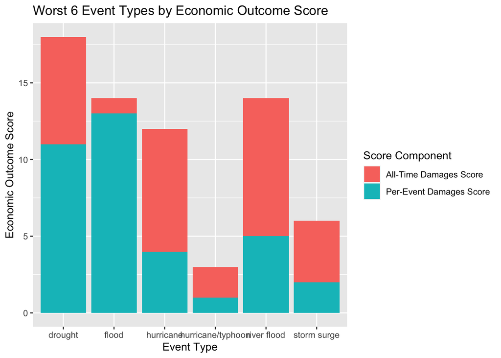

```r
worst_event_ranks_econ <- head(arrange(ranked_econ_data, econ_score), 6) %>%
    select(event_type, avg_dmg_score:total_dmg_score)
econ_plot_data <- gather(worst_event_ranks_econ, "score_type","score",-event_type)
econ_plot_data$event_type <- tolower(econ_plot_data$event_type)
econ_plot_data$score_type <- gsub("avg_dmg_score", "Per-Event Damages Score", econ_plot_data$score_type)
econ_plot_data$score_type <- gsub("total_dmg_score", "All-Time Damages Score", econ_plot_data$score_type)

ge <- ggplot(econ_plot_data, aes(x=event_type, y=score, fill=score_type))
ge <- ge + geom_bar(stat="identity")
ge <- ge + labs(x = "Event Type", y = "Economic Outcome Score", fill = "Score Component")
ge <- ge + labs(title = "Worst 6 Event Types by Economic Outcome Score")
ge
```

*This plot depicts the worst 6 event types in terms of economic damages incurred, based on our calculated economic outcome score metric. We computer the average economic damages per event and total economic damages over all events of a specific type. Then, these quantities were ranked/scored over all event types and the ranks were summed to get the economic outcome score. These component scores are displayed as well in the plot above. As we can see, the worst economic outcome scores are those of hurricanes/typhoons and storm surges, so these have the greatest economic consequences per our analysis.*

## Results

Through our analyses, we may conclude that:

1. **Excessive/extreme heat conditions** are the most harmful to population health of all event types.
2. **Hurricanes and storm surges**, which usually go hand-in-hand, are the most damaging economically of all event types.

This is not particularly surprising, given the common occurrences of heat strokes and issues with dehydration, as well as the astronomical damage figures typically heard about hurricanes and storm surges in the United States. As a next step in the health analysis, it may be worth the effort to look at other health outcomes, such as injury severity or occurrences of certain diseases/conditions as a result of certain events. For the economic analysis, damages can be analyzed within this data set further by looking at crop and property damage specifically to identify injurious events in both sectors (and potentially other sectors in the future).